International | France | USA

# Dans le monde

```
dernière mise-à-jour :  2020-05-18 07:40:46
```

### Les données

> Les données sur le Covid-19 proviennent de [Johns Hopkins (github)](https://github.com/CSSEGISandData/COVID-19/tree/master/csse_covid_19_data/csse_covid_19_daily_reports) qui les exploite [ici](https://coronavirus.jhu.edu/map.html).

```
données exploitées ici : du  02-21-2020  au  05-17-2020

Les 2 derniers jours :
```

|  | Italy | Spain | France | US | United Kingdom | Germany | Belgium | Sweden |
| --- | --- | --- | --- | --- | --- | --- | --- | --- |
| 2020-05-16 | 31763 | 27563 | 27532 | 88754 | 34546 | 7938 | 9005 | 3674 |
| 2020-05-17 | 31908 | 27563 | 28111 | 89562 | 34716 | 7962 | 9052 | 3679 |

*Remarque.* Les dates de "départ" de l'épidémie choisies dépendent des pays et des données représentées.

- **Pour les données brutes** (nombre de décès non normalisé) : Italie choisie comme modèle, autres dates déterminées de sorte que les nombres de décès coïncident le plus possible dans les 20 premiers jours avec le modèle.
- **Pour les données normalisées** (nombre de décès par millions d'habitants) : la date de départ est le premier jour où un pays a 2 décès par millions d'habitants (à plus ou moins 1 jour près).

Soit avant/après renormalisation :

|  | avant | après |
| --- | --- | --- |
| Italy | 21/02 | 05/03 |
| Spain | 29/02 | 11/03 |
| France | 03/03 | 16/03 |
| US | 05/03 | 25/03 |
| United Kingdom | 07/03 | 20/03 |
| Germany | 10/03 | 24/03 |
| Belgium | 11/03 | 19/03 |
| Sweden | / | 22/03 |

### Les graphes

- **Chiffres bruts** : les nombres encadrés donnent par pays le nombre de décès (total ou quotidien) le jour du confinement.

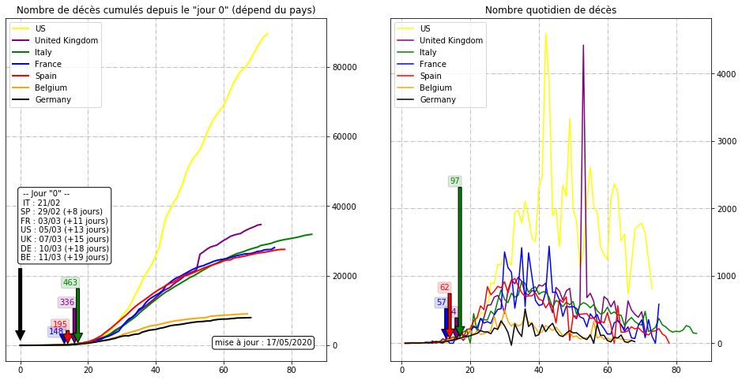

- **Chiffres re-normalisés par la population totale** : nombre de décès donné ici *par million d'habitants*.

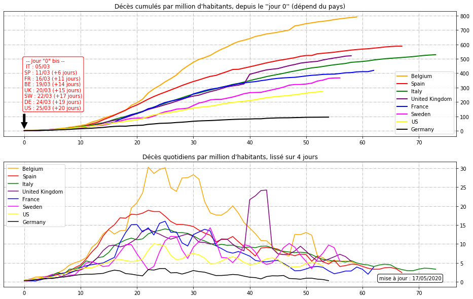

*Remarques.*

1. La comparaison Belgique/Allemagne est frappante, autant de décès (nombre brut) ... ce qui, ramené à leurs populations respectives, les place aux deux bouts du spectre (sinistre choix de mot).
2. On a ajouté la Suède aux graphes, pour que l'on arrête de nous dire que "sans confinement, les suédois s'en tirent mieux". C'est faux. Pour comprendre d'où vient cette légende, voir cette [vidéo](https://www.youtube.com/watch?v=JsRcn6zE4xM) (4:11), notamment l'extrait de LCI qui est un parangon d'enfumage.
3. Comparer "les États-Unis" à un pays européen n'a pas trop de sens. Pour mieux comprendre la situation aux US, voici des éléments.
4. Les importantes variations de la courbe des décès quotidiens en France viennent des chiffres des décès hors-hôpital qui ont commencé à arriver très tard et par grappes. Pour plus de détails (et un essai de renormalisation), voir cette page.
5. Par comparaison, les décès hors-hôpital sont arrivés en une fois au Royaume-Uni (le 30 avril / jour 40 renormalisé).

International > France >> USA